# 585Lab3

Goode, Jeppson, Papio

February 16, 2017

## Data Cleaning

First step, read in the files.

```r
file1 <- lapply(excel_sheets("spreadsheets/FileOne.xlsx"), read_excel, path = "spreadsheets/FileOne.xlsx")
file2 <- lapply(excel_sheets("spreadsheets/FileTwo.xlsx"), read_excel, path = "spreadsheets/FileTwo.xlsx")
```

Before we can combine the files, or even the semesters, we need to do a little bit of cleaning.

```r
# First up, file 1:

file1[[1]]
```

```
## # A tibble: 94 × 18
##       ``    `` `Answer 1` `Answer 2` `Answer 3` `Answer 4` `Answer 5`
##    <dbl> <chr>      <dbl>      <dbl>      <dbl>      <dbl>      <dbl>
## 1      1   Pre          7          5          5          5          7
## 2      2   Pre          9          3          2          8         10
## 3      3   Pre          8          3          7          5          7
## 4      4   Pre         10          2          6         10          8
## 5      8   Pre          8          3          6          8          5
## 6     12   Pre          7          7          9          8          3
## 7     13   Pre          9          5          4          9          8
## 8     14   Pre          2          2          2          3          2
## 9     16   Pre          7          9          8          5          8
## 10    17   Pre          5          4          7          3          7
## # ... with 84 more rows, and 11 more variables: `Answer 6` <dbl>, `Answer
## #   7` <dbl>, `Answer 8` <dbl>, `Answer 9` <dbl>, `Answer 10` <dbl>,
## #   Total <dbl>, `Normalized Changes` <dbl>, GENDER <chr>,
## #   Characteristic <chr>, `Treatment Part 1` <chr>, `Treatment Part 2
## #   ` <chr>
```

```r
# file 1 sem 1 is missing column titles
names(file1[[1]])[c(1,2)]<-c("ID", "Test")
file1[[1]] <- file1[[1]] %>% mutate ( Sem =1)


file1[[2]]
```

```
## # A tibble: 92 × 19
##       ``    `` `Answer 1` `Answer 2` `Answer 3` `Answer 4` `Answer 5`
##    <dbl> <chr>      <dbl>      <dbl>      <dbl>      <dbl>      <dbl>
## 1  20002   PRE          9          7          9          9          8
## 2  20003   PRE          6          5          5          4          4
## 3  20004   PRE          9          8          5          9          9
## 4  20005   PRE          7          1          6          7          1
## 5  20007   PRE          7          8          8          6          7
## 6  20009   PRE          8          8          7          9         10
## 7  20010   PRE          5          3          5          2          4
## 8  20011   PRE          8         10         10         10         10
## 9  20012   PRE          4          7          7          5          5
## 10 20015   PRE         10          3         10         10         10
## # ... with 82 more rows, and 12 more variables: `Answer 6` <dbl>, `Answer
## #   7` <dbl>, `Answer 8` <dbl>, `Answer 9` <dbl>, `Answer 10` <dbl>,
## #   Total <dbl>, `Normalized Changes` <dbl>, `` <dbl>, GENDER <chr>,
## #   Characteristic <chr>, `Treatment Part 1` <chr>, `Treatment Part 2
## #   ` <chr>
```

```r
# file 1 sem 2 is also missing column titles
names(file1[[2]])[c(1,2)]<-c("ID", "Test")
# delete extra column of NA's
file1[[2]] <- file1[[2]][,-15]
file1[[2]] <- file1[[2]] %>% mutate ( Sem = 2)

file1[[3]]
```

```
## # A tibble: 98 × 18
##       ``    `` `Answer 1` `Answer 2` `Answer 3` `Answer 4` `Answer 5`
##    <dbl> <chr>      <dbl>      <dbl>      <dbl>      <dbl>      <dbl>
## 1  30001   Pre          8          3          6          8          6
## 2  30002   Pre          7          8         10          8          8
## 3  30003   Pre          8          8          8          9          6
## 4  30004   Pre         10          9          9          9          9
## 5  30005   Pre          9          8          7          8          8
## 6  30006   Pre          9          9          4          9          8
## 7  30007   Pre          7          5          7          8          6
## 8  30008   Pre          8          4          9          7          4
## 9  30009   Pre         10          8          9          9         10
## 10 30010   Pre          3          1          1          3          6
## # ... with 88 more rows, and 11 more variables: `Answer 6` <dbl>, `Answer
## #   7` <dbl>, `Answer 8` <dbl>, `Answer 9` <dbl>, `Answer 10` <dbl>,
## #   Total <dbl>, `Normalized Changes` <dbl>, GENDER <chr>,
## #   Characteristic <chr>, `Treatment Part 1` <chr>, `Treatment Part 2
## #   ` <chr>
```

```r
# file 1 sem 3 is also missing column titles
names(file1[[3]])[c(1,2)]<-c("ID", "Test")
file1[[3]] <- file1[[3]] %>% mutate ( Sem =3)

file1[[4]]
```

```
## # A tibble: 74 × 18
##       ``    `` `Answer 1` `Answer 2` `Answer 3` `Answer 4` `Answer 5`
##    <dbl> <chr>      <dbl>      <dbl>      <dbl>      <dbl>      <dbl>
## 1  40101   PRE          9          8          8          8          9
## 2  40102   PRE          8          4         10         10          7
## 3  40103   PRE          2          3          4          2          3
## 4  40104   PRE          9          9          8          9          8
## 5  40105   PRE          8          9          9          9          9
## 6  40106   PRE          9          8          5          8          6
## 7  40107   PRE          9         10          8          9          8
## 8  40108   PRE          7          6          7          9          7
## 9  40109   PRE         10          7          7          9          7
## 10 40110   PRE          9          7          1         10          8
## # ... with 64 more rows, and 11 more variables: `Answer 6` <dbl>, `Answer
## #   7` <dbl>, `Answer 8` <dbl>, `Answer 9` <dbl>, `Answer 10` <dbl>,
## #   Total <dbl>, `Normalized Changes` <dbl>, GENDER <chr>,
## #   Characteristic <chr>, `Treatment Part 1` <chr>, `Treatment Part 2
## #   ` <chr>
```

```r
# file 1 sem 4 is also missing column titles
names(file1[[4]])[c(1,2)]<-c("ID", "Test")
# the ids for sem 4 have an extra 100 in them?
file1[[4]] <- file1[[4]] %>% mutate ( ID=ID -100, Sem =4)

# combine the list of data frames into one dataframe
f1 <- do.call("rbind", file1)

# make sure all "test" resposes are the same case
f1$Test <- gsub("PRE", "Pre", f1$Test)
f1$Test <- gsub("POST", "Post", f1$Test)
f1
```

```
## # A tibble: 358 × 19
##       ID  Test `Answer 1` `Answer 2` `Answer 3` `Answer 4` `Answer 5`
## *  <dbl> <chr>      <dbl>      <dbl>      <dbl>      <dbl>      <dbl>
## 1      1   Pre          7          5          5          5          7
## 2      2   Pre          9          3          2          8         10
## 3      3   Pre          8          3          7          5          7
## 4      4   Pre         10          2          6         10          8
## 5      8   Pre          8          3          6          8          5
## 6     12   Pre          7          7          9          8          3
## 7     13   Pre          9          5          4          9          8
## 8     14   Pre          2          2          2          3          2
## 9     16   Pre          7          9          8          5          8
## 10    17   Pre          5          4          7          3          7
## # ... with 348 more rows, and 12 more variables: `Answer 6` <dbl>, `Answer
## #   7` <dbl>, `Answer 8` <dbl>, `Answer 9` <dbl>, `Answer 10` <dbl>,
## #   Total <dbl>, `Normalized Changes` <dbl>, GENDER <chr>,
## #   Characteristic <chr>, `Treatment Part 1` <chr>, `Treatment Part 2
## #   ` <chr>, Sem <dbl>
```

```r
#fix names of the columns
names(f1)[c(14, 15,18)] <- c("Normalized Change", "Gender", "Treatment Part 2")
f1
```

```
## # A tibble: 358 × 19
##       ID  Test `Answer 1` `Answer 2` `Answer 3` `Answer 4` `Answer 5`
## *  <dbl> <chr>      <dbl>      <dbl>      <dbl>      <dbl>      <dbl>
## 1      1   Pre          7          5          5          5          7
## 2      2   Pre          9          3          2          8         10
## 3      3   Pre          8          3          7          5          7
## 4      4   Pre         10          2          6         10          8
## 5      8   Pre          8          3          6          8          5
## 6     12   Pre          7          7          9          8          3
## 7     13   Pre          9          5          4          9          8
## 8     14   Pre          2          2          2          3          2
## 9     16   Pre          7          9          8          5          8
## 10    17   Pre          5          4          7          3          7
## # ... with 348 more rows, and 12 more variables: `Answer 6` <dbl>, `Answer
## #   7` <dbl>, `Answer 8` <dbl>, `Answer 9` <dbl>, `Answer 10` <dbl>,
## #   Total <dbl>, `Normalized Change` <dbl>, Gender <chr>,
## #   Characteristic <chr>, `Treatment Part 1` <chr>, `Treatment Part
## #   2` <chr>, Sem <dbl>
```

```r
# Next up, file 2:

file2[[1]]
```

```
## # A tibble: 94 × 39
##       ID    `` `SO 1` `SO 2` `SO 3` `SO 4` `CI 1` `CI 2` `CI 3` `CI 4`
##    <dbl> <chr>  <dbl>  <dbl>  <dbl>  <dbl>  <dbl>  <dbl>  <dbl>  <dbl>
## 1      1   PRE      4      4      5      5      5      4      4      4
## 2      2   PRE      4      5      3      5      4      3      4      4
## 3      3   PRE      4      4      5      5      2      2      3      4
## 4      4   PRE      4      4      5      5      5      5      5      4
## 5      8   PRE      4      4      3      4      3      4      4      4
## 6     12   PRE      5      5      5      5      3      4      4      4
## 7     13   PRE      5      4      3      5      4      3      5      3
## 8     14   PRE      4      5      5      5      3      3      2      4
## 9     16   PRE      5      4      4      4      4      4      4      4
## 10    17   PRE      5      4      5      5      4      3      4      5
## # ... with 84 more rows, and 29 more variables: `IMG 1` <dbl>, `IMG
## #   2` <dbl>, `IMG 3` <dbl>, `IMG 4` <dbl>, `MTH 1` <dbl>, `MTH 2` <dbl>,
## #   `MTH 4` <dbl>, `SI 1` <dbl>, `SI 2` <dbl>, `SI 3` <dbl>, `SI 4` <dbl>,
## #   `DA 1` <dbl>, `DA 2` <dbl>, `DA 3` <dbl>, `DA 4` <dbl>, `SK 1` <dbl>,
## #   `SK 2` <dbl>, `SK 3` <dbl>, `SK 4` <dbl>, `DI 1` <dbl>, `DI 2` <dbl>,
## #   `DI 3` <dbl>, `DI 4` <dbl>, Total <dbl>, `Normalized Change` <dbl>,
## #   GENDER <chr>, Characteristic <chr>, `Treatment Part 1` <chr>,
## #   `Treatment Part 2` <chr>
```

```r
# file 1 sem 1 is missing column titles
names(file2[[1]])[c(1,2)]<-c("ID", "Test")
file2[[1]] <- file2[[1]] %>% mutate (Sem =1)


file2[[2]]
```

```
## # A tibble: 92 × 40
##       ID    `` `SO 1` `SO 2` `SO 3` `SO 4` `CI 1` `CI 2` `CI 3` `CI 4`
##    <dbl> <chr>  <dbl>  <chr>  <dbl>  <dbl>  <dbl>  <dbl>  <chr>  <dbl>
## 1  20002   PRE      4      2      3      4      2      3      3      3
## 2  20003   PRE      5      5      5      5      4      5      4      4
## 3  20004   PRE      5      4      3      4      4      4      4      4
## 4  20005   PRE      4      5      4      5      4      5      4      5
## 5  20007   PRE      5      4      5      5      4      5      2      2
## 6  20009   PRE      1      5      5      5      5      4      4      5
## 7  20010   PRE      4      4      4      4      4      3      4      5
## 8  20011   PRE      5      5      4      5      2      4      1      4
## 9  20012   PRE      4      5      5      5      4      4      4      4
## 10 20015   PRE      5      4      4      5      4      4      4      4
## # ... with 82 more rows, and 30 more variables: `IMG 1` <dbl>, `IMG
## #   2` <chr>, `IMG 3` <dbl>, `IMG 4` <chr>, `MTH 1` <chr>, `MTH 2` <dbl>,
## #   `MTH 3` <dbl>, `MTH 4` <chr>, `SI 1` <dbl>, `SI 2` <dbl>, `SI
## #   3` <dbl>, `SI 4` <dbl>, `DA 1` <dbl>, `DA 2` <chr>, `DA 3` <dbl>, `DA
## #   4` <dbl>, `SK 1` <dbl>, `SK 2` <chr>, `SK 3` <dbl>, `SK 4` <dbl>, `DI
## #   1` <dbl>, `DI 2` <dbl>, `DI 3` <dbl>, `DI 4` <dbl>, Total <dbl>,
## #   `Normalized Change` <dbl>, GENDER <chr>, Characteristic <chr>,
## #   `Treatment Part 1` <chr>, `Treatment Part 2` <chr>
```

```r
# file 2 sem 2 is also missing column titles
names(file2[[2]])[c(1,2)]<-c("ID", "Test")
file2[[2]] <- file2[[2]] %>% mutate ( Sem =2)

file2[[3]]
```

```
## # A tibble: 100 × 40
##       ID    `` `SO 1` `SO 2` `SO 3` `SO 4` `CI 1` `CI 2` `CI 3` `CI 4`
##    <dbl> <chr>  <dbl>  <dbl>  <dbl>  <dbl>  <dbl>  <dbl>  <dbl>  <dbl>
## 1  30001   Pre      1      4      5      5      4      3      5      5
## 2  30002   Pre      4      4      5      5     NA      4      5      4
## 3  30003   Pre      5      5      5      5      5      4      2      5
## 4  30004   Pre      4      3      5      5      2      4      4      5
## 5  30005   Pre      4      5      4      5      4      5      4      3
## 6  30006   Pre      4      4      3      5      4      5      4      4
## 7  30007   Pre      5      4      5      5      4      5      4     NA
## 8  30008   Pre      5      5      5      5      2      4      4      4
## 9  30009   Pre      4      4      4      4      3      4      3      4
## 10 30010   Pre      4      4      4      4      4      3      3      2
## # ... with 90 more rows, and 30 more variables: `IMG 1` <dbl>, `IMG
## #   2` <dbl>, `IMG 3` <dbl>, `IMG 4` <dbl>, `MTH 1` <dbl>, `MTH 2` <dbl>,
## #   `MTH 3` <dbl>, `MTH 4` <dbl>, `SI 1` <dbl>, `SI 2` <dbl>, `SI
## #   3` <dbl>, `SI 4` <dbl>, `DA 1` <dbl>, `DA 2` <dbl>, `DA 3` <dbl>, `DA
## #   4` <dbl>, `SK 1` <dbl>, `SK 2` <dbl>, `SK 3` <dbl>, `SK 4` <dbl>, `DI
## #   1` <dbl>, `DI 2` <dbl>, `DI 3` <dbl>, `DI 4` <dbl>, Total <dbl>,
## #   `Normalized Change` <dbl>, GENDER <chr>, Characteristic <chr>,
## #   `Treatment Part 1` <chr>, `Treatment Part 2` <chr>
```

```r
# file 2 sem 3 is also missing column titles
names(file2[[3]])[c(1,2)]<-c("ID", "Test")
file2[[3]] <- file2[[3]] %>% mutate ( Sem =3)

file2[[4]]
```

```
## # A tibble: 76 × 40
##       ID    `` `SO 1` `SO 2` `SO 3` `SO 4` `CI 1` `CI 2` `CI 3` `CI 4`
##    <dbl> <chr>  <dbl>  <dbl>  <dbl>  <dbl>  <dbl>  <dbl>  <dbl>  <dbl>
## 1  41101   Pre      4      5      5      5      4      5      4      4
## 2  41102   Pre      5      4      4      5      2      3      1      2
## 3  41103   Pre      4      2      5      5      4      2      4      4
## 4  41104   Pre      5      5      5      5      5      5      5      5
## 5  41105   Pre      4      5      5      5      4      4      4      2
## 6  41106   Pre      4      4      5      5      5      4      4      4
## 7  41107   Pre      5      5      5      5      5      5      2      4
## 8  41108   Pre      5      5      5      5      4      3      4      4
## 9  41109   Pre      5      5      3      5      5      2      4      4
## 10 41110   Pre      5      5      2      5      3      5      4      5
## # ... with 66 more rows, and 30 more variables: `IMG 1` <dbl>, `IMG
## #   2` <dbl>, `IMG 3` <dbl>, `IMG 4` <dbl>, `MTH 1` <dbl>, `MTH 2` <dbl>,
## #   `MTH 3` <dbl>, `MTH 4` <dbl>, `SI 1` <dbl>, `SI 2` <dbl>, `SI
## #   3` <dbl>, `SI 4` <dbl>, `DA 1` <dbl>, `DA 2` <dbl>, `DA 3` <dbl>, `DA
## #   4` <dbl>, `SK 1` <dbl>, `SK 2` <dbl>, `SK 3` <dbl>, `SK 4` <dbl>, `DI
## #   1` <dbl>, `DI 2` <dbl>, `DI 3` <dbl>, `DI 4` <dbl>, Total <dbl>,
## #   `Normalized Change` <dbl>, GENDER <chr>, Characteristic <chr>,
## #   `Treatment Part 1` <chr>, `Treatment Part 2` <chr>
```

```r
# file 1 sem 4 is also missing column titles
names(file2[[4]])[c(1,2)]<-c("ID", "Test")
# the ids for sem 4 have an extra 1100 in them?
file2[[4]] <- file2[[4]] %>% mutate ( ID= ID -1100, Sem =4)

# looking back throu the dimensions of all 4 semesters, semester one is missing the column "MTH 3", so we'll add in a column of NAS
file2[[1]] <- file2[[1]] %>% mutate ("MTH 3" = NA)
#but I would like the columns to still be in the same order, so I will rearrange them
file2[[1]]  <- file2[[1]][,c(1:16,41,17:40)]

# combine the list of data frames into one dataframe
f2 <- do.call("rbind", file2)

# make sure all "test" resposes are the same case
f2$Test <- gsub("PRE", "Pre", f2$Test)
f2$Test <- gsub("POST", "Post", f2$Test)
f2 %>% arrange(ID)
```

```
## # A tibble: 362 × 41
##       ID  Test `SO 1` `SO 2` `SO 3` `SO 4` `CI 1` `CI 2` `CI 3` `CI 4`
##    <dbl> <chr>  <dbl>  <chr>  <dbl>  <dbl>  <dbl>  <dbl>  <chr>  <dbl>
## 1      1   Pre      4      4      5      5      5      4      4      4
## 2      1  Post      2      4      4      5      3      4      3      4
## 3      2   Pre      4      5      3      5      4      3      4      4
## 4      2  Post      4      4      5      4      4      2      4      4
## 5      3   Pre      4      4      5      5      2      2      3      4
## 6      3  Post      4      5      3      4      4      3      4      3
## 7      4   Pre      4      4      5      5      5      5      5      4
## 8      4  Post      1      2      4      5      4      4      4      4
## 9      8   Pre      4      4      3      4      3      4      4      4
## 10     8  Post      4      5      3      4      4      4      4      4
## # ... with 352 more rows, and 31 more variables: `IMG 1` <dbl>, `IMG
## #   2` <chr>, `IMG 3` <dbl>, `IMG 4` <chr>, `MTH 1` <chr>, `MTH 2` <dbl>,
## #   `MTH 3` <dbl>, `MTH 4` <chr>, `SI 1` <dbl>, `SI 2` <dbl>, `SI
## #   3` <dbl>, `SI 4` <dbl>, `DA 1` <dbl>, `DA 2` <chr>, `DA 3` <dbl>, `DA
## #   4` <dbl>, `SK 1` <dbl>, `SK 2` <chr>, `SK 3` <dbl>, `SK 4` <dbl>, `DI
## #   1` <dbl>, `DI 2` <dbl>, `DI 3` <dbl>, `DI 4` <dbl>, Total <dbl>,
## #   `Normalized Change` <dbl>, GENDER <chr>, Characteristic <chr>,
## #   `Treatment Part 1` <chr>, `Treatment Part 2` <chr>, Sem <dbl>
```

```r
names(f2)[37]<- "Gender"
```

Now that we have the two files in two dataframes we can start working on getting them combined into one dataframe.

We have a split key so we will need to create two dataframes for each file before continuing.

First, we should extract the all the information about the student that is constant throughout the semester.

```r
keys1 <- f1 %>% select(ID, Gender, Characteristic, `Treatment Part 1`, `Treatment Part 2`, Sem)
keys2 <- f2 %>% select(ID, Gender, Characteristic, `Treatment Part 1`, `Treatment Part 2`, Sem)
#combine the two together
keys <- rbind(keys1, keys2)



#since there are duplicates, we want to pull out the unique, complete, values
keys <- unique(keys)
keys <- keys[complete.cases(keys),]
keys %>% arrange(ID)
```

```
## # A tibble: 208 × 6
##       ID Gender Characteristic `Treatment Part 1` `Treatment Part 2`   Sem
##    <dbl>  <chr>          <chr>              <chr>              <chr> <dbl>
## 1      1 Female             No                  R              No LP     1
## 2      2 Female            Yes                  R              No LP     1
## 3      3   Male            Yes                  R              No LP     1
## 4      4 Female            Yes                  R              No LP     1
## 5      8 Female             No                  R              No LP     1
## 6     12 Female             No                  R              No LP     1
## 7     13 Female             No                  R              No LP     1
## 8     14 Female             No                  R              No LP     1
## 9     16 Female             No                  R              No LP     1
## 10    17 Female             No                  R              No LP     1
## # ... with 198 more rows
```

Now we can join the f1 and f2 with our dataframe of keys

```r
#take gender and characeristic out of files 1 and 2
F1 <- f1[,-c(15:19)]
F2 <- f2[,-c(37:41)]

# Join the dataframes
first <- left_join(keys, F1, by=("ID"))
first %>% arrange(ID)
```

```
## # A tibble: 412 × 19
##       ID Gender Characteristic `Treatment Part 1` `Treatment Part 2`   Sem
##    <dbl>  <chr>          <chr>              <chr>              <chr> <dbl>
## 1      1 Female             No                  R              No LP     1
## 2      1 Female             No                  R              No LP     1
## 3      2 Female            Yes                  R              No LP     1
## 4      2 Female            Yes                  R              No LP     1
## 5      3   Male            Yes                  R              No LP     1
## 6      3   Male            Yes                  R              No LP     1
## 7      4 Female            Yes                  R              No LP     1
## 8      4 Female            Yes                  R              No LP     1
## 9      8 Female             No                  R              No LP     1
## 10     8 Female             No                  R              No LP     1
## # ... with 402 more rows, and 13 more variables: Test <chr>, `Answer
## #   1` <dbl>, `Answer 2` <dbl>, `Answer 3` <dbl>, `Answer 4` <dbl>,
## #   `Answer 5` <dbl>, `Answer 6` <dbl>, `Answer 7` <dbl>, `Answer
## #   8` <dbl>, `Answer 9` <dbl>, `Answer 10` <dbl>, Total <dbl>,
## #   `Normalized Change` <dbl>
```

```r
final <- left_join(first, F2, by=c("ID","Test"))
final %>% arrange(ID)
```

```
## # A tibble: 412 × 53
##       ID Gender Characteristic `Treatment Part 1` `Treatment Part 2`   Sem
##    <dbl>  <chr>          <chr>              <chr>              <chr> <dbl>
## 1      1 Female             No                  R              No LP     1
## 2      1 Female             No                  R              No LP     1
## 3      2 Female            Yes                  R              No LP     1
## 4      2 Female            Yes                  R              No LP     1
## 5      3   Male            Yes                  R              No LP     1
## 6      3   Male            Yes                  R              No LP     1
## 7      4 Female            Yes                  R              No LP     1
## 8      4 Female            Yes                  R              No LP     1
## 9      8 Female             No                  R              No LP     1
## 10     8 Female             No                  R              No LP     1
## # ... with 402 more rows, and 47 more variables: Test <chr>, `Answer
## #   1` <dbl>, `Answer 2` <dbl>, `Answer 3` <dbl>, `Answer 4` <dbl>,
## #   `Answer 5` <dbl>, `Answer 6` <dbl>, `Answer 7` <dbl>, `Answer
## #   8` <dbl>, `Answer 9` <dbl>, `Answer 10` <dbl>, Total.x <dbl>,
## #   `Normalized Change.x` <dbl>, `SO 1` <dbl>, `SO 2` <chr>, `SO 3` <dbl>,
## #   `SO 4` <dbl>, `CI 1` <dbl>, `CI 2` <dbl>, `CI 3` <chr>, `CI 4` <dbl>,
## #   `IMG 1` <dbl>, `IMG 2` <chr>, `IMG 3` <dbl>, `IMG 4` <chr>, `MTH
## #   1` <chr>, `MTH 2` <dbl>, `MTH 3` <dbl>, `MTH 4` <chr>, `SI 1` <dbl>,
## #   `SI 2` <dbl>, `SI 3` <dbl>, `SI 4` <dbl>, `DA 1` <dbl>, `DA 2` <chr>,
## #   `DA 3` <dbl>, `DA 4` <dbl>, `SK 1` <dbl>, `SK 2` <chr>, `SK 3` <dbl>,
## #   `SK 4` <dbl>, `DI 1` <dbl>, `DI 2` <dbl>, `DI 3` <dbl>, `DI 4` <dbl>,
## #   Total.y <dbl>, `Normalized Change.y` <dbl>
```

After joining the two dataframes, we renamed the variables corresponding to each test total score.

```r
# Renaming variables
names(final)[6] <- "Semester"
names(final)[18] <- "Test1_Total"
names(final)[52] <- "Test2_Total"
```

## Graphs Comparing Pre and Post Scores

Examining the number of IDs and unique IDs in the key dataframe created earlier, the lengths differ, due to discrepancies between the test 1 and test 2 variables for characteristic and gender. There are several examples below of students that show these discrepancies.

```r
# Comparing lengths of key IDs and unique IDs
length(keys$ID)
```

```
## [1] 208
```

```r
length(unique(keys$ID))
```

```
## [1] 182
```

```r
# Example of disagreement in characteristic value
final %>%
  filter(ID == "30033") %>%
  select(ID, Characteristic)
```

```
## # A tibble: 4 × 2
##      ID Characteristic
##   <dbl>          <chr>
## 1 30033             No
## 2 30033             No
## 3 30033            Yes
## 4 30033            Yes
```

```r
# Example of disagreement in gender value
final %>%
  filter(ID == "40030") %>%
  select(ID, Gender)
```

```
## # A tibble: 4 × 2
##      ID Gender
##   <dbl>  <chr>
## 1 40030   Male
## 2 40030   Male
## 3 40030 Female
## 4 40030 Female
```

The discrepancies from test 2 dataframe occur at the end of the final dataframe. Although it would be advised to consult with the data collaborator, the duplicates after the first 346 rows are removed on the assumption that the values from the test 1 dataframe are correct .

```r
# Removing rows with dis
final <- final %>%
  slice(1:346)
```

With these rows removed, the dataframe can be transformed into the necessary formats using functions from the *tidyr* package. The test 1 and test 2 scores are separated into two dataframes with pre and post scores in two columns. Only the variables of ID, Gender, Test, and Semester are kept. Additionally, we created a variable of the difference between the post and pre scores (Post-Pre).

To get a better feel for differences between Pre and Posttest scores, as well as differences by gender, several ways of visually comparing the pre and post scores are included below. For each test, we produce a scatterplot comparing Pre and Post scores, then side by side box plots of Pre and Post differences by gender, and lastly overlapping densities of the differences between Pre and Post by gender.

```r
# Data for test 1 scores
graph.data.1 <- final %>%
  select(ID, Gender, Test, Test1_Total, Semester) %>%
  spread(key = Test, value = Test1_Total) %>%
  mutate(Difference = Post - Pre)

# Data for test 2 scores
graph.data.2 <- final %>%
  select(ID, Gender, Test, Test2_Total, Semester) %>%
  spread(key = Test, value = Test2_Total) %>%
  mutate(Difference = Post - Pre)
```

### Test 1 Scores

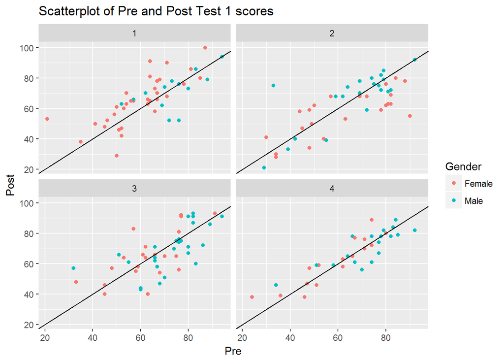

```r
ggplot(graph.data.1, aes(x = Pre, y = Post, color = Gender)) +
  geom_point() +
  geom_abline(intercept = 0, slope = 1) +
  facet_wrap( ~ Semester) +
  labs(title= "Scatterplot of Pre and Post Test 1 scores")
```

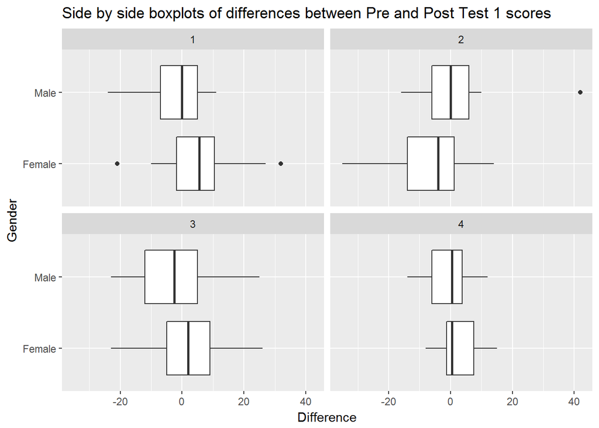

```r
ggplot(graph.data.1, aes(x = Gender, y = Difference)) +
  geom_boxplot() +
  facet_wrap( ~ Semester) +
  coord_flip() +
  labs(title= "Side by side boxplots of differences between Pre and Post Test 1 scores")
```

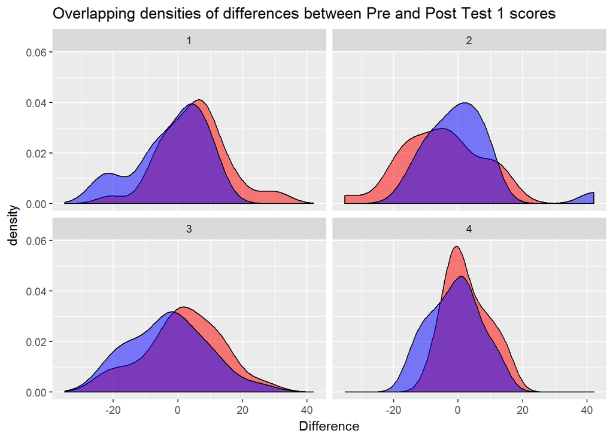

```r
ggplot(graph.data.1, aes(x = Difference)) +
  geom_density(data = subset(graph.data.1, Gender == 'Female'),fill = "red", alpha = 0.5) +
  geom_density(data = subset(graph.data.1, Gender == 'Male'),fill = "blue", alpha = 0.5) +
  facet_wrap( ~ Semester) +
  labs(title= "Overlapping densities of differences between Pre and Post Test 1 scores")
```

### Test 2 Scores

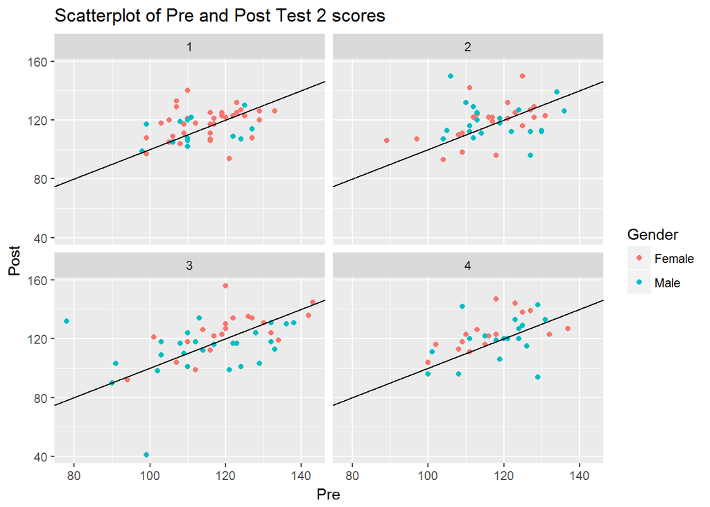

```r
ggplot(graph.data.2, aes(x = Pre, y = Post, color = Gender)) +
  geom_point() +
  geom_abline(intercept = 0, slope = 1) +
  facet_wrap( ~ Semester) +
  labs(title= "Scatterplot of Pre and Post Test 2 scores")
```

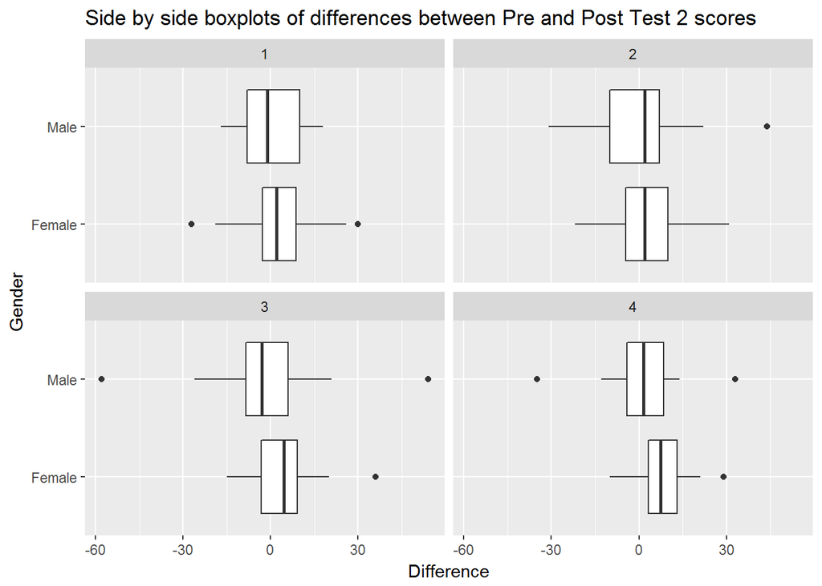

```r
ggplot(graph.data.2, aes(x = Gender, y = Difference)) +
  geom_boxplot() +
  facet_wrap( ~ Semester) +
  coord_flip()+
  labs(title= "Side by side boxplots of differences between Pre and Post Test 2 scores")
```

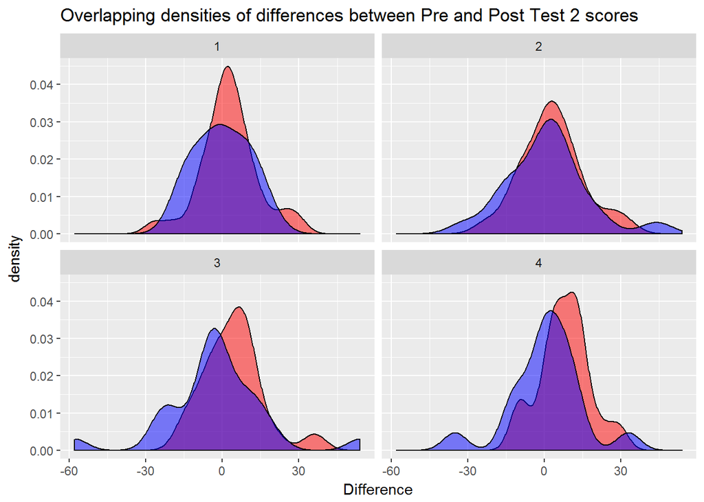

```r
ggplot(graph.data.2, aes(x = Difference)) +
  geom_density(data = subset(graph.data.2, Gender == 'Female'),fill = "red", alpha = 0.5) +
  geom_density(data = subset(graph.data.2, Gender == 'Male'),fill = "blue", alpha = 0.5) +
  facet_wrap( ~ Semester) +
  labs(title= "Overlapping densities of differences between Pre and Post Test 2 scores")
```